# Git & Github

# Outlines

- Version control
- Git & Github
- R Markdown: Note Book
- Demo

# Version control (VC)

*What is VC?*

“Version control is a system that records changes to a file or set of files over time so that you can recall specific versions later” ref: https://git-scm.com/book/en/v2/Getting-Started-About-Version-Control

VC allows you to: revert files back to a previous state, revert the entire project back to a previous state, compare changes over time, see who last modified something that might be causing a problem, who introduced an issue and when, and more. Using a VCS also generally means that if you screw things up or lose files, you can easily recover

# Git & Github

*What is git? and github?*

- git is a version control system
- A git repository (a.k.a repo) is basically a folder/directory that is under version control.
- github is a public place for hosting git repositories

*Why use git?*

- To maintain a complete history of your code and project. It’s the best way to share code, review code, and merge changes easily

*What are git verbs?*

In RStudio most commands translate directly to buttons:

- Commit: Committing is the action of storing a set of files (in a repository) to a version
- Push: After you commited your changes you push them to repo
- Pull: If collaborating as a group you pull any new things other people have changed
- Diff: Two different versions may be “diffed,” which means to reveal the changes between them
- Stage: Not all files need to be included in a version; staging a set of files marks them for inclusion in the version when the next commit happens.

You can also use the command line version, by clicking the cog and then “Shell” in the git tab in RStudio.

*How to get started?*

If you’ve never used Git or GitHub before, start by installing Git and creating a GitHub account. Then, link the two together:

1. Install git from: http://r-pkgs.had.co.nz/git.html
2. Tell Git your user.name and email. These are used to label each commit so that when you start collaborating with others, it’s clear who made each change
3. Create an account on GitHub, https://github.com
4. Create a public repo from your github account
5. create local git repo using R studio project and clone your online repo to the local one

Read if you want more details: https://support.rstudio.com/hc/en-us/articles/200532077-Version-Control-with-Git-and-SVN

# Demo

```r
son <- rnorm(200, 10,2)
summary(son)
```

```
   Min. 1st Qu.  Median    Mean 3rd Qu.    Max.
  3.691   8.637  10.110  10.060  11.410  14.990
```

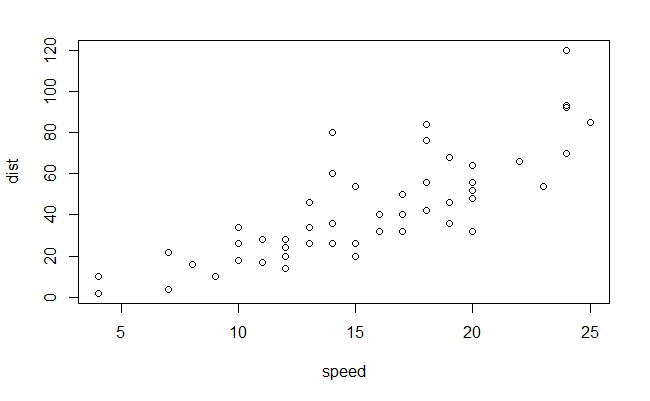

```r
plot(cars)
```

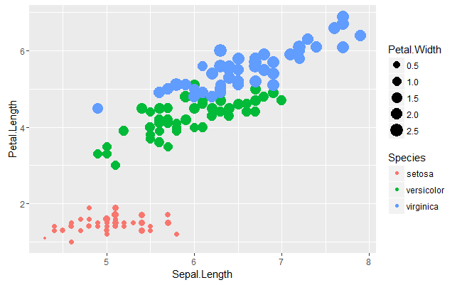

```r
ggplot2::qplot(Sepal.Length, Petal.Length, data = iris, color = Species,
      size = Petal.Width)
```